# FluSight 2021-2022 & 2022-2023 supplemental backfill analysis

CDC FluSight Team

2023-11-29

```r
library(RSocrata)
library(dplyr)
```

```r
library(ggplot2)
library(readr)
library(stringr)
select = dplyr::select
filter = dplyr::filter

#CDC UserID goes here
userid="nqr2"

#update path to where cloned GitHub repository lives
githubpath = paste0("C:/Users/",userid,"/Desktop/GitHub")
manuscript_repo <- paste0(githubpath, "/FluSight-manuscripts/HospitalAdmissionsForecasts_2021-22_2022-23")
flusight_forecast_data <-paste0(githubpath, "/Flusight-forecast-data")
source(paste0(manuscript_repo,"/functions2022-2023.R"))

flu21_target_end_dates <- c("2022-02-26", "2022-03-05", "2022-03-12", "2022-03-19", "2022-03-26", "2022-04-02","2022-04-09", "2022-04-16",
                            "2022-04-23", "2022-04-30", "2022-05-07", "2022-05-14", "2022-05-21", "2022-05-28", "2022-06-04", "2022-06-11",
                            "2022-06-18", "2022-06-25", "2022-07-02", "2022-07-09", "2022-07-16")
flu23_target_end_dates <- c("2022-10-22", "2022-10-29", "2022-11-05", "2022-11-12", "2022-11-19", "2022-11-26", "2022-12-03", "2022-12-10",
                            "2022-12-17", "2022-12-24", "2022-12-31", "2023-01-07", "2023-01-14", "2023-01-21", "2023-01-28", "2023-02-04",
                            "2023-02-11", "2023-02-18", "2023-02-25", "2023-03-04", "2023-03-11", "2023-03-18", "2023-03-25", "2023-04-01",
                            "2023-04-08", "2023-04-15", "2023-04-22", "2023-04-29", "2023-05-06", "2023-05-13", "2023-05-20", "2023-05-27" ,
                            "2023-06-03", "2023-06-10")
```

This RMD analyizes and outputs figures for the backfill analysis

```r
obs_data21 <- read_csv(paste0(flusight_forecast_data,"/data-truth/truth-Incident Hospitalizations-Archived_9-12-2022.csv")) %>%
  mutate(wk_end_date = as.Date(date, "%m/%d/%y"),
         location_name = ifelse(location == 'US', 'National', location_name)) %>%
  select(-date) %>%
  filter(wk_end_date %in% as.Date(unique(flu21_target_end_dates)), location != 78 )
obs_data21 <- obs_data21 %>%
  rename(value_inc = value,
         target_end_date = wk_end_date) %>%
  filter(target_end_date < Sys.Date())

obs_data23 <- read_csv(paste0(flusight_forecast_data,"/data-truth/truth-Incident Hospitalizations.csv")) %>%
  mutate(wk_end_date = as.Date(date, "%m/%d/%y"),
         location_name = ifelse(location == 'US', 'National', location_name)) %>%
  select(-date) %>%
  filter(wk_end_date %in% as.Date(unique(flu23_target_end_dates)), location != 78)
obs_data23 <- obs_data23 %>%
  dplyr::rename(value_inc = value,
                target_end_date = wk_end_date) %>%
  filter(target_end_date < Sys.Date())
```

##### Backfill epicurve

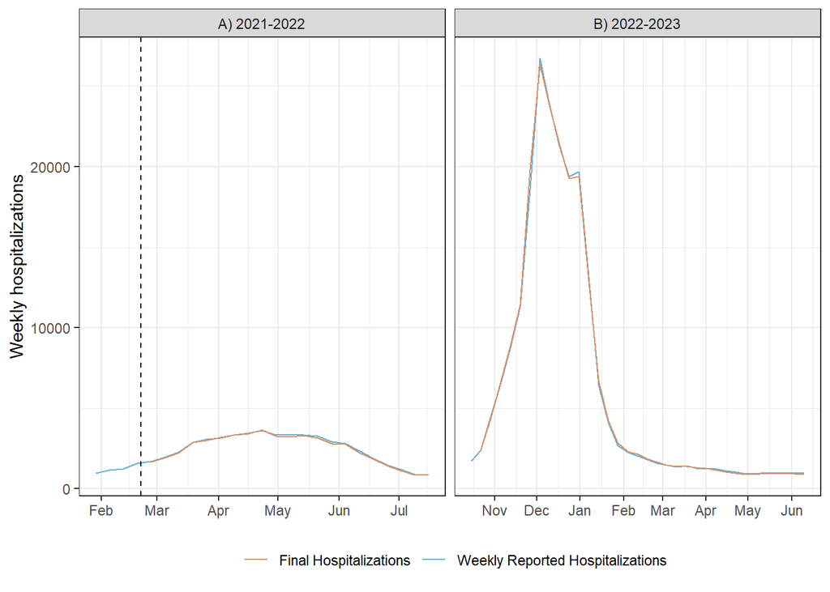

```r
#Data are pulled via the api for both Tuesday and Mondays. Monday pulls are in a function sourced from functions2022-2023
#Tuesday data pull
tues_start <- as.Date("2023-01-17")
tues_end <- as.Date("2023-06-13")

tuesdates <- seq(from = tues_start, to = tues_end, by = 7)

jsonpath <- read.socrata(url = "https://healthdata.gov/resource/qqte-vkut.json")

tues_set <- data.frame(state = character(), date = as.Date(character()), value = integer(), report_date = character(), epiweek = character(), epiyear = character())
d <- tues_start

#loop to pull in api data and aggregate it weekly
while (d <= last(tuesdates)){
   d = as.Date(d, origin = "1970-01-01")
   #if there are multiple updates on the same day, we want to pull in the later update rather than an earlier update
  filename = case_when(length(jsonpath[str_detect(string = jsonpath$update_date, pattern = as.character(d)), 12]) > 1 ~
                         jsonpath[str_detect(string = jsonpath$update_date, pattern = as.character(d)), 12][2],
                           TRUE ~  jsonpath[str_detect(string = jsonpath$update_date, pattern = as.character(d)), 12][1])

    #print(d)
    df = read.csv(filename) %>% mutate(date = as.Date(date, tryFormats = c("%Y-%m-%d", "%m/%d/%Y", "%Y/%m/%d")) -1)
    df1 = df %>% filter(as.Date(date, tryFormats = c("%Y-%m-%d", "%m/%d/%Y", "%Y/%m/%d")) > as.Date(d-10), date < as.Date(d - 2), state != "AS", state != "VI") %>%
      select(state, date, previous_day_admission_influenza_confirmed) %>%
      mutate(date = as.Date(date, tryFormats = c("%Y-%m-%d", "%m/%d/%Y", "%Y/%m/%d")), report_date = (as.Date((get_next_saturday(d) - 7), "%Y-%m-%d")), epiweek = epiweek(date), epiyear = epiyear(date), .keep = "all") %>%
      rename(value = previous_day_admission_influenza_confirmed) %>% select(state, date, value, report_date, epiweek, epiyear)
    tues_set = rbind(tues_set, df1)
    d <- d + 7
}
#pulling 2021-22 data for backfill and summarizing nationally
finalset21 <- backfilldata_func(startdate = "2022-01-31", enddate = "2022-07-18")
forecastdata21 <- nation_summary_func(finalset21)
#renaming and creating some new variables to make comparison easier
truthtransmute21 <-  obs_data21  %>% transmute(location_name = case_when(location_name == "National" ~ "US", TRUE ~ location_name),
                                             wk_end_date = as.Date(target_end_date), value = as.numeric(as.character(value_inc)),
                                           report_date  = as.Date("2022-09-12")) %>%
  filter(wk_end_date >= "2022-01-01")

#add the transmuted data to the original truth data
truthaddon21 <- truthtransmute21 %>% filter(location_name == "US") %>%
  rename(truthdate = report_date, date = wk_end_date, truthvalue = value) %>%
  group_by(truthdate, date) %>% ungroup()


fullset21 <- forecastdata21 %>% filter(state == "US") %>% left_join(., truthaddon21, by = c("state" = "location_name", "report_date" = "date" ))

finalset23 <- backfilldata_func("2022-10-17","2023-01-09")
finalset23 <- rbind(finalset23, tues_set)
forecastdata23 <- nation_summary_func(finalset23)
truthtransmute23 <-  obs_data23  %>% transmute(location_name = case_when(location_name == "National" ~ "US", TRUE ~ location_name),
                                             wk_end_date = as.Date(target_end_date), value = as.numeric(as.character(value_inc)),
                                           report_date  = as.Date("2023-05-20")) %>%
  filter(wk_end_date >= "2022-10-22")

truthaddon23 <- truthtransmute23 %>% filter(location_name == "US") %>%
  rename(truthdate = report_date, date = wk_end_date, truthvalue = value) %>%
  group_by(truthdate, date) %>% ungroup()


fullset23 <- forecastdata23 %>% filter(state == "US") %>% left_join(., truthaddon23, by = c("state" = "location_name", "report_date" = "date" ))

fullset <- rbind(mutate(fullset21, season = "A) 2021-2022"), mutate(fullset23, season = "B) 2022-2023"))


wklyplt <-
  ggplot(fullset, aes(x = report_date)) +
  geom_line(aes(y = value, color = "Weekly Reported Hospitalizations"))+
  geom_line(aes(y = truthvalue, color = "Final Hospitalizations"))+
  scale_x_date(date_breaks = "1 month", date_labels = "%b") +
  geom_vline(aes(xintercept = as.Date("2022-02-21")), linetype = "dashed")+
  labs(y = "Weekly hospitalizations",  x = NULL) +
  scale_color_manual(name = NULL, values = c("Weekly Reported Hospitalizations" = "#6baed6", "Final Hospitalizations" = "#d6936b"))+
  theme_bw() +
  theme(legend.position="bottom")+
  facet_grid(cols = vars(season), scales = "free_x")

wklyplt
```

```r
#
# ggsave(plot = wklyplt, paste0(manuscript_repo,"/Output/backfill_epicurv_mon_tue.png"), height = 6, width = 8, dpi = 300)
```

##### Backfill Differences

```r
diffdf21 <- diff_df_function(truthtransmute21, forecastdata21) %>% mutate(season = "A) 2021-2022")
diffdf23 <- diff_df_function(truthtransmute23, forecastdata23) %>% mutate(season = "B) 2022-2023")

diffdf <- rbind(diffdf21, diffdf23)

dffsummary <- diffdf %>% filter (location_name != "Virgin Islands") %>% group_by(season, location_name) %>%
  summarise(meanpercdiff = mean(final_perc_change, na.rm= TRUE),
            perclow = min(final_perc_change, na.rm = TRUE),
            perchigh = max(final_perc_change, na.rm =  TRUE),
            perciqr = IQR(final_perc_change, na.rm = TRUE),
            perc_median = median(final_perc_change, na.rm = TRUE),
            meanabsolute = mean(absolutediff, na.rm = TRUE),
            absolow = min(absolutediff, na.rm = TRUE),
            absohigh = max(absolutediff, na.rm = TRUE),
            absoiqr = IQR(absolutediff, na.rm = TRUE),
            median = median(absolutediff, na.rm = TRUE)) %>% ungroup
write.csv(dffsummary, paste0(manuscript_repo,"/Output/backfill_difference_summary.csv"), row.names = FALSE)




statediffs21 <- diffdf %>% filter(state != "US", season == "A) 2021-2022", !is.na(absolutediff))
statediffs23 <- diffdf %>% filter(state != "US", season == "B) 2022-2023", !is.na(absolutediff))
```

## Backfill Analysis

### 2021-2022

To assess potential impacts of changes in reported values on forecast performance, we compared reported incident hospitalizations
$$REF HHS-Protect$$
at the time they would have been used for forecasts to the values used in evaluating forecasts (Supplemental Figures S2-S4). Revisions to published data changed between seasons. During the 2021-22 season, most data updates occurred within one month of when the data were initially published, and 12 out of the 18 weeks that were analyzed did not have updates two weeks after initial publication. In 2022-23, prior to the week ending December 19, most data updates occurred within one month of when the data were initially published, similar to 2021-22. Subsequently, data were updated more frequently over a longer period. For both seasons, across all subnational forecast jurisdictions, a majority (93.96% in 21-22 and 82.98% in 22-23) of final values changed by less than 10 hospitalizations or did not change compared to corresponding initial reports. In 2021-22, a higher percent of updates had final values lower than initial reports, 37.91%, compared to 30.83 in 2022-23. Conversely, 2022-23 had a higher percent of updates with no change (38.46%) than the 2021-22 season (31.68%. Both seasons had similar percent of updates with final values higher than initial reports (30.71%) 30.4%, for 2022-23 and 2021-22 respectively).

Jurisdiction-specific median percent differences had a larger range in 2021-22 from -14.29% in Rhode Island to 7.14% in Oregon whereas, percent differences ranged from -5.9% in Arizona to 4.39% in Illinois for 2022-23. Across states, DC, and Puerto Rico, and for both seasons, the median numeric difference between initial report and final report was 0. Supplemental figures S2-S4 for additional information on the distribution of differences between final reported values used for evaluation and the initial reported values. Supplemental figures S2-S4 for additional information on the distribution of differences between final reported values used for evaluation and the initial reported values.

##### Absolute Difference

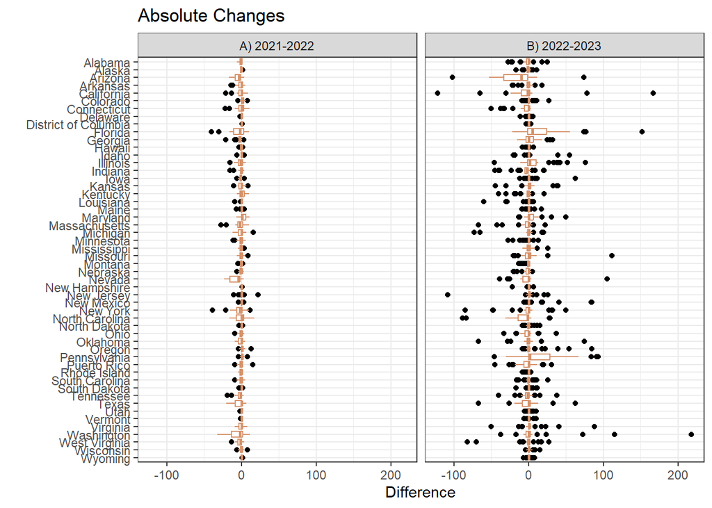

```r
absoplt <- diffdf %>% filter(location_name != "US") %>%
  ggplot(aes(x = absolutediff, y = location_name))+
  geom_boxplot(color = "#d6936b", outlier.color = "black")+
  scale_y_discrete( limits = rev) +
  labs(x = "Difference", y = "", title = "Absolute Changes")+
  theme_bw()+
  facet_grid(cols = vars(season))

absoplt
```

```r
 # ggsave(plot = absoplt,  paste0(manuscript_repo,"/Output/Numeric_difference_all.png"), width = 6, height = 8, dpi = 300)
```

##### Relative Differences

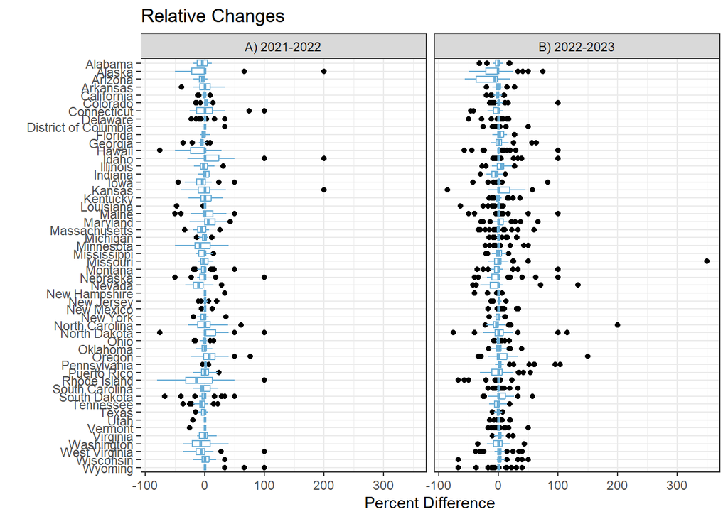

```r
percplt <- diffdf %>% filter(location_name != "US") %>% #can take out != National
  ggplot(aes(x = final_perc_change*100, y = location_name))+
  geom_boxplot(color = "#6baed6", outlier.color = "black")+
  scale_y_discrete( limits = rev) +
  labs(x = "Percent Difference", y = "", title = "Relative Changes")+
  theme_bw()+
facet_grid(cols = vars(season))
percplt
```

```r
# ggsave(plot = percplt, paste0(manuscript_repo,"/Output/Percent_difference_all.png"), width = 6, height = 8, dpi = 300)
```

##### Backfill matrix plot

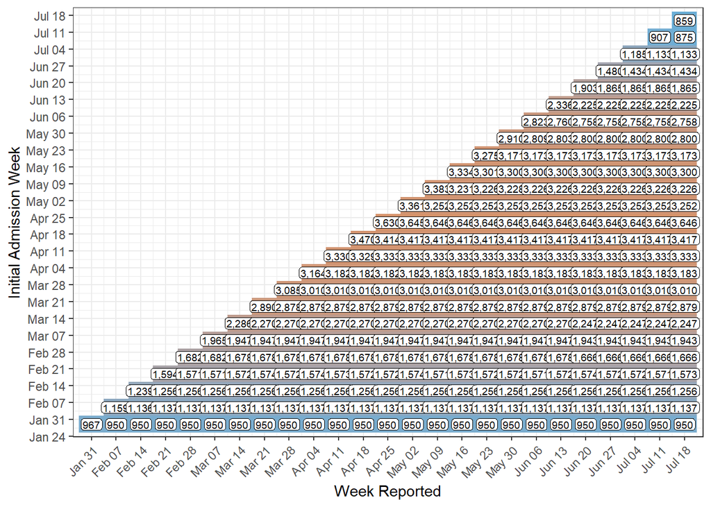

```r
weeklydat21 <- hosp_data_read_func(from = as.Date("2022-01-31"), to = as.Date("2022-07-18"))
weeklydat23 <- hosp_data_read_func(from = as.Date("2022-10-10"), to = as.Date("2023-01-09"))
weeklydat23a <- hosp_data_read_func(from = as.Date("2022-10-11"), to = as.Date("2023-06-13"), tuesday = TRUE) %>% filter(report_date >= "2023-01-17")


weeklydat23 <- rbind(weeklydat23, weeklydat23a)

####check start date
stairstep_function <- function(weeklydat, fromdate, todate){
matrixset <-  weeklydat %>% group_by(report_date, epiweek) %>%
  summarise(value = sum(value, na.rm = TRUE), date = as.Date(max(date)), asof = as.Date(date + 2)) %>%
  ungroup() %>% #filter(date > as.Date("2022-01-29"), date < as.Date("2022-06-21")) %>%
  select(-epiweek)


log10limlow <- min(log10(matrixset$value))
log10limhigh <- max(log10(matrixset$value))

stairplt <-
matrixset %>%
  ggplot(aes(y = date,x= report_date))+
  geom_tile(aes( fill = log10(value)))+
  theme_bw()+
  geom_label(aes(label = scales::comma(value)), label.padding = unit(.09, "lines"), size = 2.5)+
  scale_fill_gradient(name = NULL,low = "#6baed6", high = "#d6936b", limits = c(log10limlow, log10limhigh)) +
  scale_y_date(date_breaks = "1 week", date_labels = "%b %d", expand = c(0.01,0.01))+
  scale_x_date(date_breaks = "1 week", date_labels = "%b %d", expand = c(0.01,0.01))+
  labs(x = "Week Reported", y = "Initial Admission Week")+
  theme(legend.position = "none",
        axis.text.x = element_text(angle = 45, hjust = 1))
return(stairplt)
}

stairplt21 <- stairstep_function(weeklydat21)
stairplt23 <- stairstep_function(weeklydat23)
stairplt21
```

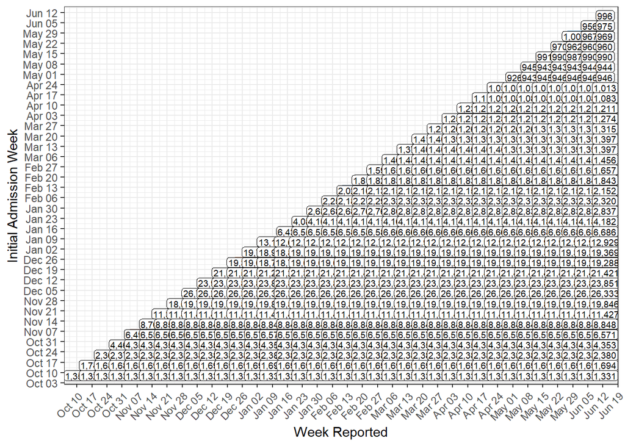

```r
stairplt23
```

```r
# ggsave(plot = stairplt21,  paste0(manuscript_repo,"/Output/stairstep21.png"), width = 8, height = 6, dpi = 300)
# ggsave(plot = stairplt23,  paste0(manuscript_repo,"/Output/stairstep23.png"), width = 12, height = 8, dpi = 300)
```